# Assignment 3b: Window Functions

Kenny Jeannite

2026-09-20

## Introduction

For this assignment, I am using Steam player data to compare Dota 2 and Counter-Strike: Global Offensive during 2019. The main question I want to answer is: how does each game’s recent player activity compare with its average since the beginning of the year?

I will use window functions in dplyr to calculate the year-to-date average and the six-day moving average for each game. I will then use a line chart to compare the six-day averages for both games.

## Loading the Data

The data comes from the [Steam Games Dataset on Mendeley Data](https://data.mendeley.com/datasets/ycy3sy3vj2/1) in 2020. The original files contain player counts recorded every five minutes.

Here I am loading that CSV and putting the dates in order for each game. The dataset contains 365 days for each game, from January 1 through December 31, 2019. The daily average represents how many people were playing at the same time, rather than the total number of different people who played that day.

```r
daily_players <- read.csv("https://raw.githubusercontent.com/kjeannite/data-607/refs/heads/master/assignment-3b/steam_daily_2019.csv") %>%
  select(game, date, daily_avg_players) %>%
  mutate(date = as.Date(date), year = format(date, "%Y")) %>%
  arrange(game, date)

head(daily_players)
```

```
##                               game       date daily_avg_players year
## 1 Counter-Strike: Global Offensive 2019-01-01          386773.6 2019
## 2 Counter-Strike: Global Offensive 2019-01-02          406566.7 2019
## 3 Counter-Strike: Global Offensive 2019-01-03          396416.1 2019
## 4 Counter-Strike: Global Offensive 2019-01-04          423967.7 2019
## 5 Counter-Strike: Global Offensive 2019-01-05          460969.9 2019
## 6 Counter-Strike: Global Offensive 2019-01-06          445969.2 2019
```

## Year-to-Date Average

Here I am using `cummean()` to calculate the average from January 1 through each date. Grouping by game and year keeps the games separate and starts the calculation over for each year.

```r
player_averages <- daily_players %>%
  group_by(game, year) %>%
  mutate(ytd_avg = cummean(daily_avg_players)) %>%
  ungroup()

head(player_averages)
```

```
## # A tibble: 6 × 5
##   game                             date       daily_avg_players year  ytd_avg
##   <chr>                            <date>                 <dbl> <chr>   <dbl>
## 1 Counter-Strike: Global Offensive 2019-01-01           386774. 2019  386774.
## 2 Counter-Strike: Global Offensive 2019-01-02           406567. 2019  396670.
## 3 Counter-Strike: Global Offensive 2019-01-03           396416. 2019  396585.
## 4 Counter-Strike: Global Offensive 2019-01-04           423968. 2019  403431.
## 5 Counter-Strike: Global Offensive 2019-01-05           460970. 2019  414939.
## 6 Counter-Strike: Global Offensive 2019-01-06           445969. 2019  420111.
```

## Six-Day Moving Average

Next I am calculating the average for the current day and the previous five days. The `lag()` function lets me use the values from those earlier days. I add the six values together and divide by six, keeping the calculation separate for each game.

There are no missing dates in the daily dataset, so six rows represent six calendar days. The first five results are `NA` because there are not yet six days available to average.

```r
player_averages <- player_averages %>%
  group_by(game) %>%
  arrange(date, .by_group = TRUE) %>%
  mutate(moving_avg_6 = (
    daily_avg_players +
      lag(daily_avg_players, 1) +
      lag(daily_avg_players, 2) +
      lag(daily_avg_players, 3) +
      lag(daily_avg_players, 4) +
      lag(daily_avg_players, 5)
  ) / 6) %>%
  ungroup()

player_averages %>%
  group_by(game) %>%
  slice_head(n = 7) %>%
  knitr::kable(digits = 2)
```

| game | date | daily_avg_players | year | ytd_avg | moving_avg_6 |
| --- | --- | --- | --- | --- | --- |
| Counter-Strike: Global Offensive | 2019-01-01 | 386773.6 | 2019 | 386773.6 | NA |
| Counter-Strike: Global Offensive | 2019-01-02 | 406566.7 | 2019 | 396670.2 | NA |
| Counter-Strike: Global Offensive | 2019-01-03 | 396416.0 | 2019 | 396585.5 | NA |
| Counter-Strike: Global Offensive | 2019-01-04 | 423967.7 | 2019 | 403431.0 | NA |
| Counter-Strike: Global Offensive | 2019-01-05 | 460969.9 | 2019 | 414938.8 | NA |
| Counter-Strike: Global Offensive | 2019-01-06 | 445969.2 | 2019 | 420110.5 | 420110.5 |
| Counter-Strike: Global Offensive | 2019-01-07 | 387813.3 | 2019 | 415496.6 | 420283.8 |
| Dota 2 | 2019-01-01 | 434344.1 | 2019 | 434344.1 | NA |
| Dota 2 | 2019-01-02 | 440703.5 | 2019 | 437523.8 | NA |
| Dota 2 | 2019-01-03 | 433800.6 | 2019 | 436282.7 | NA |
| Dota 2 | 2019-01-04 | 450088.4 | 2019 | 439734.2 | NA |
| Dota 2 | 2019-01-05 | 496994.2 | 2019 | 451186.2 | NA |
| Dota 2 | 2019-01-06 | 489939.0 | 2019 | 457645.0 | 457645.0 |
| Dota 2 | 2019-01-07 | 439165.3 | 2019 | 455005.0 | 458448.5 |

### Checking the Moving Average

Here I am checking the first six-day average for Dota 2. The average of the first six daily values should match the moving average on January 6.

```r
player_averages %>%
  filter(game == "Dota 2") %>%
  slice(1:6) %>%
  summarise(
    manual_average = mean(daily_avg_players),
    moving_average = last(moving_avg_6)
  )
```

```
## # A tibble: 1 × 2
##   manual_average moving_average
##            <dbl>          <dbl>
## 1        457645.        457645.
```

## Comparing the Player Counts

Below I am graphing the six-day moving average for both games. Each colored line represents one game, making it easier to compare their player counts over time.

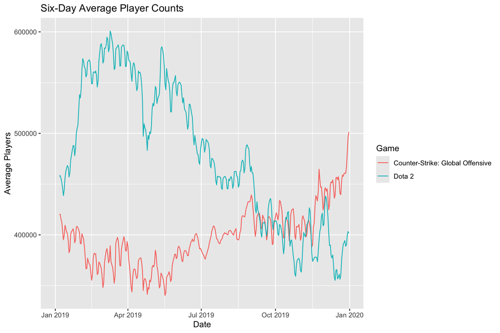

```r
ggplot(player_averages,
       aes(x = date, y = moving_avg_6, color = game)) +
  geom_line(na.rm = TRUE) +
  labs(
    title = "Six-Day Average Player Counts",
    x = "Date",
    y = "Average Players",
    color = "Game"
  )
```

The six-day average smooths some of the daily changes in player counts. A higher line means that game had more concurrent players on average over the most recent six days.

Here I am looking at the final day of the year to compare the results for both games.

```r
player_averages %>%
  filter(date == as.Date("2019-12-31")) %>%
  select(game, ytd_avg, moving_avg_6) %>%
  knitr::kable(digits = 2)
```

| game | ytd_avg | moving_avg_6 |
| --- | --- | --- |
| Counter-Strike: Global Offensive | 398659.6 | 501241.6 |
| Dota 2 | 478071.9 | 401752.5 |

## Conclusion

Dota 2 had the higher average for the full year, at about 478,072 concurrent players compared with 398,660 for Counter-Strike: Global Offensive. However, Counter-Strike had the higher average over the final six days. This shows why looking at recent activity can give a different picture than looking at the whole year.

This assignment helped me see how window functions can summarize changes over time while keeping each game separate. One limitation is that some five-minute readings were missing. I left those out when calculating the daily averages and kept recorded zeros, so the results still depend on the quality of the original data.